# - Régression logistique binaire BIRTHWT

1. Charger le jeu de données 'birthwt' du package 'MASS' dans R.
2. Étude descriptive des différentes variables de 'birthwt'.
3. Diviser la base de données en 90% pour l'apprentissage et 10% pour la validation.
4. Tester l'association de la variable 'low' avec les autres variables par régression logistique binaire.
5. Évaluer les indicateurs de performance de prédiction du modèle choisi.
6. Transformer les variables 'ftv' et 'ptl' en variables qualitatives.
7. Diviser la nouvelle base de données après le codage des variables 'ftv' et 'ptl'.
8. Évaluer les indicateurs de performance du modèle choisi avec le package 'blorr'.

### Présentation des donnèes birthwt :

- low : Variable binaire (0 ou 1) indiquant si le poids du bébé à la naissance est faible (1) ou non (0).
- age : Âge de la mère en années.
- lwt : Poids de la mère au dernier cycle menstruel avant la grossesse (en livres).
- race : Catégorie raciale de la mère (représentée par des entiers, par exemple 1 pour une race, 2 pour une autre, etc.).
- smoke : Variable binaire indiquant si la mère fumait (1) ou non (0) pendant la grossesse.
- ptl : Nombre de grossesses antérieures avec un accouchement prématuré.
- ht : Variable binaire indiquant si la mère a des antécédents d'hypertension (1) ou non (0).
- ui : Variable binaire indiquant la présence (1) ou l'absence (0) d'irritabilité utérine.
- ftv : Nombre de visites chez le médecin au premier trimestre de la grossesse.
- bwt : Poids du bébé à la naissance (en grammes).

Chaque variable représente un facteur potentiel influençant le poids du bébé à la naissance, utile pour l'analyse statistique et la modélisation.

```r
# Installation des packages nécessaires pour l'analyse
install.packages('MASS')    # Installation de MASS pour des fonctions statistiques et des jeux de données
install.packages('questionr') # Installation de questionr pour des fonctions utiles en statistiques, y compris le calcul des Odds Ratios
install.packages("blorr")   # Installation de blorr pour des analyses et visualisations avancées de la régression logistique
install.packages("dplyr")   # Installation de dplyr pour la manipulation de données et des opérations de traitement de données
```

```r
library("MASS")    # Chargement du package MASS. Il contient des fonctions pour l'analyse statistique et des jeux de données.

library("questionr") # Chargement du package questionr. Utile pour des fonctions d'analyse statistique, notamment pour les Odds Ratios.

library("ROCR")    # Chargement du package ROCR. Ce package est utilisé pour évaluer les performances des modèles prédictifs, notamment via la courbe ROC.

library("blorr")   # Chargement du package blorr. Fournit des outils pour l'analyse et la visualisation de modèles de régression logistique.

library("psych")   # Chargement du package psych. Il est utile pour les analyses psychométriques et la description statistique des données.
```

##### 1. Charger le jeu de données 'birthwt'

```r
data("birthwt", package = "MASS") # charger dataset
print(head(birthwt)) # afficher
```

```
   low age lwt race smoke ptl ht ui ftv  bwt
85   0  19 182    2     0   0  0  1   0 2523
86   0  33 155    3     0   0  0  0   3 2551
87   0  20 105    1     1   0  0  0   1 2557
88   0  21 108    1     1   0  0  1   2 2594
89   0  18 107    1     1   0  0  1   0 2600
91   0  21 124    3     0   0  0  0   0 2622
```

#### 2. Étude descriptive des différentes variables

```r
head(birthwt)  # afficher les premiers lignes
```

A data.frame: 6 × 10

|  | low <int> | age <int> | lwt <int> | race <int> | smoke <int> | ptl <int> | ht <int> | ui <int> | ftv <int> | bwt <int> |
| --- | --- | --- | --- | --- | --- | --- | --- | --- | --- | --- |
| 85 | 0 | 19 | 182 | 2 | 0 | 0 | 0 | 1 | 0 | 2523 |
| 86 | 0 | 33 | 155 | 3 | 0 | 0 | 0 | 0 | 3 | 2551 |
| 87 | 0 | 20 | 105 | 1 | 1 | 0 | 0 | 0 | 1 | 2557 |
| 88 | 0 | 21 | 108 | 1 | 1 | 0 | 0 | 1 | 2 | 2594 |
| 89 | 0 | 18 | 107 | 1 | 1 | 0 | 0 | 1 | 0 | 2600 |
| 91 | 0 | 21 | 124 | 3 | 0 | 0 | 0 | 0 | 0 | 2622 |

```r
tail(birthwt) #afficher les derniers
```

A data.frame: 6 × 10

[output not shown]

```r
str(birthwt)#ptl ftv
```

```
'data.frame':	189 obs. of  10 variables:
 $ low  : int  0 0 0 0 0 0 0 0 0 0 ...
 $ age  : int  19 33 20 21 18 21 22 17 29 26 ...
 $ lwt  : int  182 155 105 108 107 124 118 103 123 113 ...
 $ race : int  2 3 1 1 1 3 1 3 1 1 ...
 $ smoke: int  0 0 1 1 1 0 0 0 1 1 ...
 $ ptl  : int  0 0 0 0 0 0 0 0 0 0 ...
 $ ht   : int  0 0 0 0 0 0 0 0 0 0 ...
 $ ui   : int  1 0 0 1 1 0 0 0 0 0 ...
 $ ftv  : int  0 3 1 2 0 0 1 1 1 0 ...
 $ bwt  : int  2523 2551 2557 2594 2600 2622 2637 2637 2663 2665 ...
```

=> Chaque variable représente un facteur potentiel influençant le poids du bébé à la naissance, utile pour l'analyse statistique et la modélisation.

```r
dim(birthwt) # dimension
```

1. 189

2. 10

### Convertir les variable en facteurs

=> Les variables (race, low, smoke, ht, ui) des variables à la conversion en facteurs, en raison de leur nature catégorielle (binaire ou nominale).

```r
birthwt$race= as.factor(birthwt$race) # # Convertir la variable 'race' en facteur
birthwt$race
```

1. 2

2. 3

3. 1

4. 1

5. 1

6. 3

7. 1

8. 3

9. 1

10. 1

11. 3

12. 3

13. 3

14. 3

15. 1

16. 1

17. 2

18. 1

19. 3

20. 1

21. 3

22. 1

23. 1

24. 3

25. 3

26. 1

27. 1

28. 1

29. 2

30. 2

31. 2

32. 1

33. 2

34. 1

35. 2

36. 1

37. 1

38. 1

39. 1

40. 1

41. 2

42. 1

43. 2

44. 1

45. 1

46. 1

47. 1

48. 3

49. 1

50. 3

51. 1

52. 3

53. 1

54. 1

55. 3

56. 3

57. 3

58. 3

59. 3

60. 3

61. 3

62. 3

63. 3

64. 1

65. 3

66. 3

67. 3

68. 3

69. 1

70. 2

71. 1

72. 3

73. 3

74. 2

75. 1

76. 2

77. 1

78. 1

79. 2

80. 1

81. 1

82. 1

83. 3

84. 3

85. 3

86. 3

87. 3

88. 1

89. 1

90. 1

91. 1

92. 3

93. 1

94. 1

95. 1

96. 1

97. 1

98. 1

99. 1

100. 1

101. 1

102. 1

103. 3

104. 1

105. 3

106. 2

107. 1

108. 1

109. 1

110. 2

111. 1

112. 3

113. 1

114. 1

115. 1

116. 3

117. 1

118. 3

119. 1

120. 3

121. 1

122. 3

123. 1

124. 1

125. 1

126. 1

127. 1

128. 1

129. 1

130. 1

131. 3

132. 1

133. 2

134. 3

135. 3

136. 3

137. 3

138. 2

139. 3

140. 1

141. 1

142. 1

143. 3

144. 3

145. 1

146. 1

147. 2

148. 1

149. 3

150. 3

151. 3

152. 1

153. 1

154. 1

155. 1

156. 3

157. 2

158. 1

159. 2

160. 3

161. 1

162. 3

163. 3

164. 3

165. 2

166. 1

167. 3

168. 3

169. 1

170. 1

171. 2

172. 2

173. 2

174. 3

175. 3

176. 1

177. 1

178. 1

179. 1

180. 2

181. 3

182. 3

183. 1

184. 3

185. 1

186. 3

187. 3

188. 2

189. 1

**Levels**:**

1. '1'

2. '2'

3. '3'

```r
=> On a 3 niveaux
```

Le résultat de birthwt$race montre les données brutes converties en facteurs, avec des niveaux indiquant les différentes catégories raciales présentes dans nos données.

```r
birthwt$smoke= as.factor(birthwt$smoke) # Convertir la variable 'smoke' en facteur
birthwt$smoke
```

1. 0

2. 0

3. 1

4. 1

5. 1

6. 0

7. 0

8. 0

9. 1

10. 1

11. 0

12. 0

13. 0

14. 0

15. 1

16. 1

17. 0

18. 1

19. 0

20. 1

21. 0

22. 0

23. 0

24. 0

25. 0

26. 0

27. 1

28. 0

29. 1

30. 0

31. 0

32. 1

33. 1

34. 0

35. 0

36. 1

37. 1

38. 1

39. 1

40. 1

41. 1

42. 0

43. 0

44. 0

45. 1

46. 1

47. 0

48. 0

49. 0

50. 1

51. 0

52. 0

53. 1

54. 1

55. 0

56. 0

57. 1

58. 0

59. 0

60. 0

61. 0

62. 0

63. 0

64. 0

65. 1

66. 0

67. 0

68. 1

69. 0

70. 0

71. 1

72. 1

73. 1

74. 0

75. 1

76. 0

77. 0

78. 1

79. 1

80. 0

81. 0

82. 0

83. 0

84. 0

85. 0

86. 1

87. 0

88. 0

89. 0

90. 0

91. 0

92. 0

93. 1

94. 1

95. 1

96. 0

97. 0

98. 1

99. 1

100. 0

101. 0

102. 1

103. 0

104. 0

105. 0

106. 0

107. 0

108. 0

109. 1

110. 0

111. 0

112. 0

113. 1

114. 0

115. 1

116. 0

117. 0

118. 0

119. 0

120. 0

121. 0

122. 0

123. 0

124. 0

125. 0

126. 0

127. 0

128. 1

129. 0

130. 0

131. 1

132. 0

133. 1

134. 0

135. 0

136. 0

137. 0

138. 0

139. 0

140. 1

141. 1

142. 1

143. 0

144. 0

145. 1

146. 1

147. 0

148. 1

149. 0

150. 0

151. 0

152. 0

153. 1

154. 1

155. 0

156. 1

157. 1

158. 1

159. 0

160. 1

161. 1

162. 0

163. 0

164. 0

165. 1

166. 1

167. 0

168. 0

169. 1

170. 0

171. 1

172. 1

173. 1

174. 0

175. 0

176. 1

177. 1

178. 1

179. 1

180. 0

181. 0

182. 0

183. 1

184. 1

185. 1

186. 0

187. 1

188. 0

189. 1

**Levels**:**

1. '0'

2. '1'

```r
birthwt$ht= as.factor(birthwt$ht) # # Convertir la variable 'ht' en facteur
birthwt$ht
```

1. 0

2. 0

3. 0

4. 0

5. 0

6. 0

7. 0

8. 0

9. 0

10. 0

11. 0

12. 0

13. 1

14. 0

15. 0

16. 0

17. 0

18. 0

19. 0

20. 0

21. 0

22. 0

23. 0

24. 0

25. 0

26. 0

27. 0

28. 0

29. 0

30. 0

31. 0

32. 0

33. 0

34. 0

35. 0

36. 0

37. 0

38. 0

39. 0

40. 0

41. 0

42. 0

43. 0

44. 0

45. 0

46. 0

47. 0

48. 0

49. 0

50. 0

51. 1

52. 0

53. 0

54. 0

55. 0

56. 0

57. 0

58. 0

59. 0

60. 0

61. 0

62. 0

63. 0

64. 0

65. 0

66. 0

67. 0

68. 0

69. 0

70. 0

71. 0

72. 0

73. 0

74. 0

75. 0

76. 0

77. 0

78. 0

79. 0

80. 0

81. 0

82. 0

83. 0

84. 0

85. 0

86. 0

87. 0

88. 0

89. 0

90. 0

91. 0

92. 0

93. 1

94. 0

95. 0

96. 0

97. 0

98. 0

99. 0

100. 0

101. 0

102. 1

103. 0

104. 0

105. 0

106. 1

107. 0

108. 0

109. 0

110. 0

111. 0

112. 0

113. 0

114. 0

115. 0

116. 0

117. 0

118. 0

119. 0

120. 0

121. 0

122. 0

123. 0

124. 0

125. 0

126. 0

127. 0

128. 0

129. 0

130. 0

131. 0

132. 0

133. 1

134. 1

135. 0

136. 0

137. 0

138. 0

139. 1

140. 1

141. 0

142. 0

143. 0

144. 0

145. 0

146. 0

147. 0

148. 0

149. 0

150. 0

151. 0

152. 0

153. 0

154. 0

155. 0

156. 0

157. 0

158. 0

159. 0

160. 0

161. 0

162. 0

163. 0

164. 0

165. 0

166. 0

167. 0

168. 0

169. 0

170. 0

171. 0

172. 0

173. 0

174. 0

175. 0

176. 0

177. 0

178. 0

179. 0

180. 0

181. 1

182. 0

183. 0

184. 0

185. 0

186. 0

187. 0

188. 1

189. 1

**Levels**:**

1. '0'

2. '1'

=> On a 2 niveaux

```r
birthwt$ui=as.factor(birthwt$ui) #  ui
birthwt$ui
```

1. 1

2. 0

3. 0

4. 1

5. 1

6. 0

7. 0

8. 0

9. 0

10. 0

11. 0

12. 0

13. 0

14. 1

15. 0

16. 0

17. 0

18. 0

19. 1

20. 0

21. 0

22. 1

23. 0

24. 0

25. 1

26. 0

27. 0

28. 0

29. 0

30. 0

31. 0

32. 0

33. 0

34. 0

35. 0

36. 0

37. 0

38. 0

39. 0

40. 0

41. 0

42. 0

43. 0

44. 0

45. 1

46. 1

47. 0

48. 0

49. 0

50. 0

51. 0

52. 0

53. 0

54. 0

55. 0

56. 0

57. 1

58. 0

59. 0

60. 0

61. 0

62. 0

63. 0

64. 0

65. 0

66. 1

67. 0

68. 0

69. 1

70. 0

71. 0

72. 0

73. 0

74. 0

75. 0

76. 0

77. 0

78. 0

79. 0

80. 0

81. 0

82. 0

83. 0

84. 0

85. 0

86. 0

87. 0

88. 0

89. 0

90. 0

91. 0

92. 0

93. 0

94. 1

95. 0

96. 0

97. 0

98. 0

99. 0

100. 0

101. 0

102. 0

103. 0

104. 0

105. 0

106. 0

107. 0

108. 0

109. 0

110. 0

111. 0

112. 0

113. 0

114. 1

115. 0

116. 0

117. 0

118. 0

119. 0

120. 0

121. 0

122. 0

123. 0

124. 0

125. 0

126. 0

127. 0

128. 0

129. 0

130. 0

131. 1

132. 1

133. 0

134. 0

135. 1

136. 0

137. 1

138. 0

139. 0

140. 0

141. 0

142. 1

143. 0

144. 0

145. 0

146. 0

147. 1

148. 0

149. 0

150. 1

151. 0

152. 0

153. 1

154. 0

155. 0

156. 1

157. 0

158. 1

159. 1

160. 1

161. 0

162. 0

163. 0

164. 0

165. 0

166. 1

167. 0

168. 0

169. 0

170. 0

171. 0

172. 0

173. 0

174. 1

175. 0

176. 0

177. 0

178. 0

179. 0

180. 0

181. 0

182. 0

183. 0

184. 0

185. 0

186. 0

187. 0

188. 0

189. 0

**Levels**:**

1. '0'

2. '1'

=> On a 2 niveaux

```r
birthwt$low= as.factor(birthwt$low) # low
birthwt$low
```

1. 0

2. 0

3. 0

4. 0

5. 0

6. 0

7. 0

8. 0

9. 0

10. 0

11. 0

12. 0

13. 0

14. 0

15. 0

16. 0

17. 0

18. 0

19. 0

20. 0

21. 0

22. 0

23. 0

24. 0

25. 0

26. 0

27. 0

28. 0

29. 0

30. 0

31. 0

32. 0

33. 0

34. 0

35. 0

36. 0

37. 0

38. 0

39. 0

40. 0

41. 0

42. 0

43. 0

44. 0

45. 0

46. 0

47. 0

48. 0

49. 0

50. 0

51. 0

52. 0

53. 0

54. 0

55. 0

56. 0

57. 0

58. 0

59. 0

60. 0

61. 0

62. 0

63. 0

64. 0

65. 0

66. 0

67. 0

68. 0

69. 0

70. 0

71. 0

72. 0

73. 0

74. 0

75. 0

76. 0

77. 0

78. 0

79. 0

80. 0

81. 0

82. 0

83. 0

84. 0

85. 0

86. 0

87. 0

88. 0

89. 0

90. 0

91. 0

92. 0

93. 0

94. 0

95. 0

96. 0

97. 0

98. 0

99. 0

100. 0

101. 0

102. 0

103. 0

104. 0

105. 0

106. 0

107. 0

108. 0

109. 0

110. 0

111. 0

112. 0

113. 0

114. 0

115. 0

116. 0

117. 0

118. 0

119. 0

120. 0

121. 0

122. 0

123. 0

124. 0

125. 0

126. 0

127. 0

128. 0

129. 0

130. 0

131. 1

132. 1

133. 1

134. 1

135. 1

136. 1

137. 1

138. 1

139. 1

140. 1

141. 1

142. 1

143. 1

144. 1

145. 1

146. 1

147. 1

148. 1

149. 1

150. 1

151. 1

152. 1

153. 1

154. 1

155. 1

156. 1

157. 1

158. 1

159. 1

160. 1

161. 1

162. 1

163. 1

164. 1

165. 1

166. 1

167. 1

168. 1

169. 1

170. 1

171. 1

172. 1

173. 1

174. 1

175. 1

176. 1

177. 1

178. 1

179. 1

180. 1

181. 1

182. 1

183. 1

184. 1

185. 1

186. 1

187. 1

188. 1

189. 1

**Levels**:**

1. '0'

2. '1'

=> On a 2 niveaux

```r
table(birthwt$low)
```

```
  0   1
130  59
```

indique qu'il y a :

- 130 occurrences où low est 0 (c'est-à-dire, les cas où les bébés ne sont pas de faible poids à la naissance)
  - 59 occurrences où low est 1 (c'est-à-dire, les cas où les bébés sont de faible poids à la naissance).
- La fonction table= => produit un tableau de fréquence pour la variable low dans le jeu de données birthwt.

```r
table(birthwt$ui)
```

```
  0   1
161  28
```

ndique qu'il y a:

- 161 occurrences où ui est 0 (c'est-à-dire, les cas où il n'y a pas d'irritabilité utérine)
- 28 occurrences où ui est 1 (c'est-à-dire, les cas où il y a irritabilité utérine).
- La fonction table= => produit un tableau de fréquence pour la variable ui dans le jeu de données birthwt.

```r
table(birthwt$ht)# classe minoritaire
```

```
  0   1
177  12
```

indique que dans cet ensemble de données:

- 177 femmes n'ont pas d'antécédents d'hypertension (ht égal à 0)
- 12 femmes ont des antécédents d'hypertension (ht égal à 1)
- Ici, les femmes sans antécédents d'hypertension constituent la majorité (classe majoritaire), tandis que celles avec des antécédents d'hypertension sont nettement moins nombreuses, formant la classe minoritaire.
- La fonction table= => produit un tableau de fréquence pour la variable ht dans le jeu de données birthwt.

```r
table(birthwt$smoke)
```

```
  0   1
115  74
```

```r
table(birthwt$race)
```

```
 1  2  3
96 26 67
```

```r
table(birthwt$ptl)
```

```
  0   1   2   3
159  24   5   1
```

```r
table(birthwt$ftv)
```

```
  0   1   2   3   4   6
100  47  30   7   4   1
```

```r
summary(birthwt)
```

```
 low          age             lwt        race   smoke        ptl
 0:130   Min.   :14.00   Min.   : 80.0   1:96   0:115   Min.   :0.0000
 1: 59   1st Qu.:19.00   1st Qu.:110.0   2:26   1: 74   1st Qu.:0.0000
         Median :23.00   Median :121.0   3:67           Median :0.0000
         Mean   :23.24   Mean   :129.8                  Mean   :0.1958
         3rd Qu.:26.00   3rd Qu.:140.0                  3rd Qu.:0.0000
         Max.   :45.00   Max.   :250.0                  Max.   :3.0000
 ht      ui           ftv              bwt
 0:177   0:161   Min.   :0.0000   Min.   : 709
 1: 12   1: 28   1st Qu.:0.0000   1st Qu.:2414
                 Median :0.0000   Median :2977
                 Mean   :0.7937   Mean   :2945
                 3rd Qu.:1.0000   3rd Qu.:3487
                 Max.   :6.0000   Max.   :4990
```

- low : 130 cas où le poids à la naissance n'est pas faible (0), et 59 cas où il est faible (1).
- age : Âges des mères variant de 14 à 45 ans, avec une moyenne d'environ 23 ans.
- lwt : Poids des mères avant la grossesse variant de 80 à 250 livres, moyenne d'environ 130 livres.
- race : Répartition raciale avec 96 de la catégorie 1, 26 de la catégorie 2, et 67 de la catégorie 3.
- smoke : 115 mères ne fumant pas (0) et 74 fumant (1) pendant la grossesse.
- ptl : Nombre de grossesses antérieures avec accouchement prématuré allant de 0 à 3.
- ht : 177 mères sans antécédents d'hypertension (0) et 12 avec (1).
- ui : 161 mères sans irritabilité utérine (0) et 28 avec (1).
- ftv : Nombre de visites chez le médecin au premier trimestre de la grossesse allant de 0 à 6.
- bwt : Poids du bébé à la naissance allant de 709 à 4990 grammes.

```r
data=birthwt
```

A psych: 1 × 13

|  | vars <dbl> | n <dbl> | mean <dbl> | sd <dbl> | median <dbl> | trimmed <dbl> | mad <dbl> | min <dbl> | max <dbl> | range <dbl> | skew <dbl> | kurtosis <dbl> | se <dbl> |
| --- | --- | --- | --- | --- | --- | --- | --- | --- | --- | --- | --- | --- | --- |
| X1 | 1 | 189 | 23.2381 | 5.298678 | 23 | 22.89542 | 5.9304 | 14 | 45 | 31 | 0.7107606 | 0.5307806 | 0.3854221 |

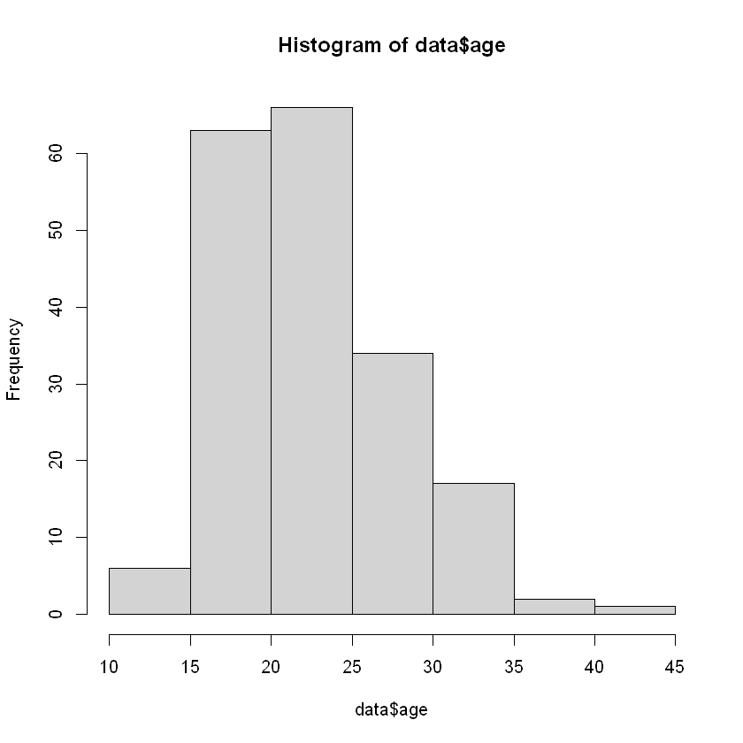

```r
describe(birthwt$age)
hist(data$age)
```

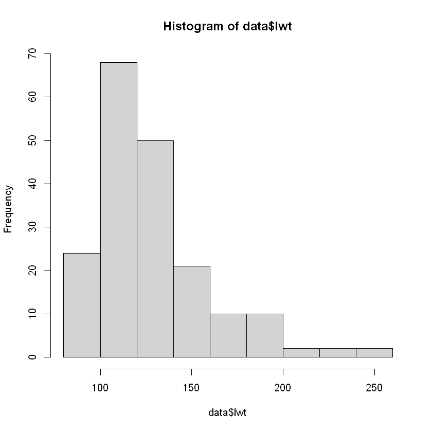

```r
hist(data$lwt)
```

```r
table(data$smoke)
birthwt=data
```

```
  0   1
115  74
```

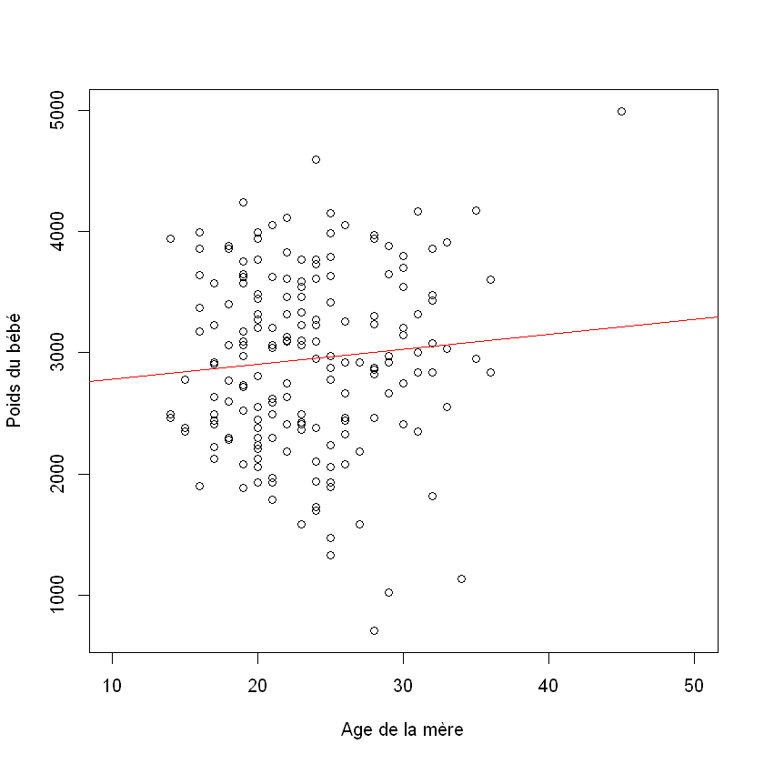

```r
# Tracé du poids du bébé en fonction de l'âge de la mère
plot(birthwt$age, birthwt$bwt,
     xlab="Age de la mère",
     ylab="Poids du bébé",
     xlim=c(10,50),
     ylim=c(700,5000))
# Cette commande crée un graphique à points (scatterplot) avec l'âge de la mère sur l'axe des x et le poids du bébé sur l'axe des y.

# Ajout d'une ligne de régression
abline(lm(bwt ~ age, data=birthwt), col="red")
# Cette ligne ajoute une ligne de régression linéaire au graphique, représentant la tendance du poids du bébé en fonction de l'âge de la mère.
```

- Le graphique montre la dispersion des poids des bébés par rapport à l'âge de leurs mères. La tendance générale, indiquée par la ligne rouge, représente la régression linéaire ajustée entre ces deux variables.
- Il semble que l'âge de la mère n'ait pas une influence forte sur le poids du bébé à la naissance, étant donné que la pente de la ligne de régression est proche de l'horizontale.
  - => Cela suggère qu'il n'y a pas de corrélation linéaire évidente entre l'âge de la mère et le poids de son bébé à la naissance dans cet ensemble de données.

##### 3. Division des données pour l'apprentissage et la validation

```r
data = subset(birthwt ,select= -bwt)
head(data)
```

A data.frame: 6 × 9

|  | low <fct> | age <int> | lwt <int> | race <fct> | smoke <fct> | ptl <int> | ht <fct> | ui <fct> | ftv <int> |
| --- | --- | --- | --- | --- | --- | --- | --- | --- | --- |
| 85 | 0 | 19 | 182 | 2 | 0 | 0 | 0 | 1 | 0 |
| 86 | 0 | 33 | 155 | 3 | 0 | 0 | 0 | 0 | 3 |
| 87 | 0 | 20 | 105 | 1 | 1 | 0 | 0 | 0 | 1 |
| 88 | 0 | 21 | 108 | 1 | 1 | 0 | 0 | 1 | 2 |
| 89 | 0 | 18 | 107 | 1 | 1 | 0 | 0 | 1 | 0 |
| 91 | 0 | 21 | 124 | 3 | 0 | 0 | 0 | 0 | 0 |

```r
# Cette ligne initialise la graine du générateur de nombres aléatoires avec la valeur 123.
set.seed(123)
# Cette ligne crée un vecteur 'index_train' contenant un échantillon aléatoire de 90 % des indices de lignes de la variable 'data'.
index_train = sample(1:nrow(data), 0.9 * nrow(data))
# Cette ligne crée un nouveau jeu de données 'data_train' en extrayant les lignes de 'data' correspondant aux indices stockés dans 'index_train'.
data_train = data[index_train,]
# Cette ligne crée un autre jeu de données 'data_test' en extrayant les lignes de 'data' qui ne sont pas incluses dans 'index_train'.
data_test = data[-index_train,]
# Cette ligne affiche les six premières lignes de la variable 'data'.
head(data)
```

A data.frame: 6 × 9

|  | low <fct> | age <int> | lwt <int> | race <fct> | smoke <fct> | ptl <int> | ht <fct> | ui <fct> | ftv <int> |
| --- | --- | --- | --- | --- | --- | --- | --- | --- | --- |
| 85 | 0 | 19 | 182 | 2 | 0 | 0 | 0 | 1 | 0 |
| 86 | 0 | 33 | 155 | 3 | 0 | 0 | 0 | 0 | 3 |
| 87 | 0 | 20 | 105 | 1 | 1 | 0 | 0 | 0 | 1 |
| 88 | 0 | 21 | 108 | 1 | 1 | 0 | 0 | 1 | 2 |
| 89 | 0 | 18 | 107 | 1 | 1 | 0 | 0 | 1 | 0 |
| 91 | 0 | 21 | 124 | 3 | 0 | 0 | 0 | 0 | 0 |

```r
str(data)
```

```
'data.frame':	189 obs. of  9 variables:
 $ low  : Factor w/ 2 levels "0","1": 1 1 1 1 1 1 1 1 1 1 ...
 $ age  : int  19 33 20 21 18 21 22 17 29 26 ...
 $ lwt  : int  182 155 105 108 107 124 118 103 123 113 ...
 $ race : Factor w/ 3 levels "1","2","3": 2 3 1 1 1 3 1 3 1 1 ...
 $ smoke: Factor w/ 2 levels "0","1": 1 1 2 2 2 1 1 1 2 2 ...
 $ ptl  : int  0 0 0 0 0 0 0 0 0 0 ...
 $ ht   : Factor w/ 2 levels "0","1": 1 1 1 1 1 1 1 1 1 1 ...
 $ ui   : Factor w/ 2 levels "0","1": 2 1 1 2 2 1 1 1 1 1 ...
 $ ftv  : int  0 3 1 2 0 0 1 1 1 0 ...
```

- low : Une variable de ty"pe factor avec 2 niveaux ("0" et "1"). Il s'agit probablement d'une variable binaire où "0" et "1" représentent différentes catégories.
- age : Une variable numérique représentant l'âge des individus dans l'échantillon.
- lwt : Une variable numérique représentant une mesure appelée "lwt".
- race : Une variable de type factor avec 3 niveaux ("1", "2" et "3"). Il s'agit probablement de la race ou de l'origine ethnique des individus.
- smoke : Une variable de type factor avec 2 niveaux ("0" et "1"). Il s'agit probablement d'une variable binaire indiquant si les individus fument ("1") ou ne fument pas ("0").
- ptl : Une variable numérique représentant une mesure appelée "ptl".
- ht : Une variable de type factor avec 2 niveaux ("0" et "1"). Il s'agit probablement d'une variable binaire indiquant la présence ("1") ou l'absence ("0") .
- ui : Une variable de type factor avec 2 niveaux ("0" et "1"). Il s'agit probablement d'une variable binaire indiquant la présence ("1") ou l'absence ("0") .
- ftv : Une variable numérique représentant une mesure appelée "ftv".

=> Ces informations indiquent la nature des variables dans notre ensemble de données, et elles seront utiles pour comprendre et analyser les données plus en détail.

```r
cat("Number of training data:", nrow(data_train), "\n")
cat("Test data count:", nrow(data_tes), "\n")
```

```
Number of training data: 170
Test data count: 19
```

```r
#y et x sont quatitatives
```

##### 4. Régression logistique binaire

La régression logistique binaire repose sur le modèle logistique, qui utilise la fonction de lien logit pour transformer les probabilités en une relation linéaire avec les prédicteurs. Le modèle est formulé comme suit :

- log(p / (1 - p)) = β0 + β1X1 + β2X2 + ... + βn*Xn

où :

- p représente la probabilité que la variable dépendante soit égale à 1 (classe positive).
- β0 est l'intercept du modèle.
- β1, β2, ..., βn sont les coefficients associés aux variables indépendantes X1, X2, ..., Xn. La fonction logit transforme le rapport des probabilités en une relation linéaire.
- La variable "y" étant qualitative donc utilisation la fonction "glm" avec une famille binomiale et une fonction de lien logit pour modéliser la relation entre "y" et les autres variables explicatives.
- Les modèles "glm" sont adaptés pour traiter des variables de réponse catégorielles, et la famille binomiale avec une fonction de lien logit est couramment utilisée pour les variables binaires (0/1).
- Cette approche permet de modéliser de manière flexible les relations complexes entre les variables, ce qui peut être crucial pour capturer des tendances non linéaires ou des interactions significatives dans vos données.

```r
modelcomplet = glm(low~.,data=data_train,family=binomial(link="logit"))
```

Calcul de l'AIC (Critère d'Information d'Akaike) pour évaluer la qualité du modèle

- L'AIC est un indicateur de la qualité d'ajustement du modèle qui prend en compte la parcimonie.
- Il est utilisé pour comparer différents modèles statistiques.
- Plus l'AIC est bas, meilleur est le modèle en termes d'ajustement et de complexité.

```r
#  nous calculons l'AIC pour le modèle "modelcomplet".
aic_value = AIC(modelcomplet)
```

```r
aic_value # affichage aic
```

198.660641656826

#### 4.a Sélection automatique du modèle avec 'step'

```r
final_model =step(modelcomplet,direction ="both")
```

```
Start:  AIC=198.66
low ~ age + lwt + race + smoke + ptl + ht + ui + ftv

        Df Deviance    AIC
- ftv    1   178.71 196.71
- age    1   178.72 196.72
- ptl    1   180.53 198.53
<none>       178.66 198.66
- ui     1   181.07 199.07
- race   2   185.51 201.51
- smoke  1   185.50 203.50
- ht     1   186.38 204.38
- lwt    1   186.48 204.48

Step:  AIC=196.71
low ~ age + lwt + race + smoke + ptl + ht + ui

        Df Deviance    AIC
- age    1   178.79 194.79
- ptl    1   180.59 196.59
<none>       178.71 196.71
- ui     1   181.16 197.16
+ ftv    1   178.66 198.66
- race   2   185.95 199.95
- smoke  1   185.90 201.90
- ht     1   186.59 202.59
- lwt    1   186.81 202.81

Step:  AIC=194.79
low ~ lwt + race + smoke + ptl + ht + ui

        Df Deviance    AIC
- ptl    1   180.61 194.61
<none>       178.79 194.79
- ui     1   181.32 195.32
+ age    1   178.71 196.71
+ ftv    1   178.72 196.72
- race   2   186.75 198.75
- smoke  1   186.10 200.10
- ht     1   186.74 200.74
- lwt    1   187.49 201.49

Step:  AIC=194.61
low ~ lwt + race + smoke + ht + ui

        Df Deviance    AIC
<none>       180.61 194.61
+ ptl    1   178.79 194.79
- ui     1   184.16 196.16
+ ftv    1   180.55 196.55
+ age    1   180.59 196.59
- race   2   188.82 198.82
- ht     1   188.73 200.73
- smoke  1   189.91 201.91
- lwt    1   190.27 202.27
```

une sélection automatique de modèle en utilisant la méthode 'step'.

*La première sortie affiche le modèle initial avec toutes les variables explicatives.

- Le modèle est évalué en fonction de l'AIC (Critère d'Information d'Akaike).
- L'AIC est un indicateur de qualité de modèle qui prend en compte l'ajustement et la complexité du modèle.
- Ensuite, le modèle est simplifié itérativement en retirant ou en ajoutant des variables explicatives pour minimiser l'AIC.
- Chaque étape du processus est résumée avec les informations suivantes :
- - Df : Le nombre de degrés de liberté du modèle.
- - Deviance : La déviance du modèle, une mesure de l'ajustement aux données.
- - AIC : L'AIC à cette étape du processus.
- => L'objectif est de trouver un modèle plus simple (avec un AIC plus bas) qui conserve un bon ajustement aux données.
- La dernière étape affiche le modèle final sélectionné avec les variables retenues.
- Le modèle final est celui qui a l'AIC le plus bas parmi toutes les étapes du processus.
- En fin de compte, 'final_model' contient le modèle sélectionné par la méthode 'step' avec les variables les plus informatives.

```r
summary(final_model)  #Modèle de régression logistique binaire
```

```
Call:
glm(formula = low ~ lwt + race + smoke + ht + ui, family = binomial(link = "logit"),
    data = data_train)

Coefficients:
             Estimate Std. Error z value Pr(>|z|)
(Intercept)  0.502479   1.008920   0.498  0.61846
lwt         -0.021184   0.007507  -2.822  0.00477 **
race2        1.292847   0.575504   2.246  0.02467 *
race3        1.099402   0.467031   2.354  0.01857 *
smoke1       1.272949   0.433461   2.937  0.00332 **
ht1          1.979115   0.719804   2.750  0.00597 **
ui1          0.912342   0.482836   1.890  0.05882 .
---
Signif. codes:  0 '***' 0.001 '**' 0.01 '*' 0.05 '.' 0.1 ' ' 1

(Dispersion parameter for binomial family taken to be 1)

    Null deviance: 214.03  on 169  degrees of freedom
Residual deviance: 180.61  on 163  degrees of freedom
AIC: 194.61

Number of Fisher Scoring iterations: 4
```

##### Explication

- Le modèle évalue l'effet des variables explicatives (lwt, race, smoke, ht, ui) sur la variable binaire "low".
- Coefficients : Estimation des coefficients pour chaque variable explicative.
  - Les coefficients indiquent la direction (positive/négative) et la force de l'effet sur la probabilité de "low".
- Les étoiles (*) représentent le niveau de signification statistique :
- *** : Très significatif (p < 0.001)
- ** : Significatif (p < 0.01)
- - : Légèrement significatif (p < 0.05)
- . : Non significatif (p > 0.05)
- Null deviance : La déviance du modèle nul (sans variables explicatives).
- Residual deviance : La déviance résiduelle du modèle final (avec variables explicatives).
  - La différence entre les deux indique l'amélioration du modèle avec les variables explicatives.
- AIC : Critère d'Information d'Akaike pour évaluer la qualité du modèle.
  - Plus l'AIC est bas, meilleur est le modèle en termes d'ajustement et de complexité.
- Nombre d'itérations de Fisher Scoring : Indique le nombre d'itérations effectuées lors de l'estimation des coefficients.
- Le modèle final sélectionné inclut les variables significatives (lwt, race, smoke, ht) et évalue leur effet sur "low".

#### 4.b AIC du modèle

```r
aic_value = AIC(final_model)
print(aic_value)
```

```
[1] 194.6087
```

La valeur de l'AIC (Critère d'Information d'Akaike) obtenue est de 194.6087.

- L'AIC est un indicateur de qualité de modèle qui prend en compte à la fois l'ajustement aux données et la complexité du modèle.
- un AIC plus bas est préférable car il indique un meilleur équilibre entre l'ajustement du modèle et sa simplicité.
- Dans ce contexte, une valeur de 194.6087 indique que le modèle final sélectionné (probablement le modèle résultant de la régression logistique binaire) est relativement bon en termes d'ajustement aux données tout en étant assez parcimonieux.

#### 4.c Vérification des valeurs influentes

```r
influences = influence.measures(final_model)
print(influences)
```

```
Influence measures of
	 glm(formula = low ~ lwt + race + smoke + ht + ui, family = binomial(link = "logit"),      data = data_train) :

       dfb.1_   dfb.lwt  dfb.rac2 dfb.rac3 dfb.smk1   dfb.ht1   dfb.ui1   dffit
43   0.015520 -0.009955  0.240501 -0.05073 -0.10263 -0.013310  0.269270  0.4183
69   0.092863 -0.063170 -0.061298 -0.07651  0.08298 -0.021166 -0.073809  0.2277
99  -0.009075  0.023514 -0.016754 -0.08968  0.03939 -0.014802 -0.246842 -0.3121
57   0.177717 -0.057059 -0.137310 -0.23011 -0.20850 -0.029341 -0.076093  0.2984
137 -0.086815  0.177900 -0.098782 -0.24554 -0.27126 -0.031751  0.078602 -0.3874
214  0.018499 -0.031487  0.013300 -0.04209  0.02082  0.026365  0.026772 -0.0985
130 -0.038086  0.017622 -0.123308  0.03433  0.05910  0.025158  0.021878 -0.1824
82   0.022146 -0.067132  0.046411  0.13006  0.14084  0.007615 -0.039214  0.1915
78   0.004564 -0.051674  0.046468  0.14411  0.15367  0.000726 -0.041420  0.2030
34   0.022941 -0.024077 -0.030995 -0.05087  0.06607  0.006270  0.194950  0.2561
184 -0.022544 -0.003880  0.031441  0.04623  0.04337  0.011516  0.014623 -0.0606
```

[output cut: 330 more lines]

- Dfbetas (dfb.*) : Ces valeurs indiquent combien chaque estimation de coefficient change lorsqu'une observation spécifique est omise.
- Par exemple, dfb.lwt représente le changement dans le coefficient pour la variable lwt quand cette observation est retirée. - Des valeurs importantes (en termes absolus) indiquent des observations ayant une influence substantielle sur les estimations des coefficients.
- Dffit : Cela mesure l'impact d'une observation sur les valeurs ajustées. Une grande valeur absolue de dffit indique que l'observation est influente en termes de valeurs prédites.
- Rapport de covariance (cov.r) : Il mesure l'impact de la suppression d'une observation sur la matrice de covariance.
- Des valeurs éloignées de 1 indiquent des observations influentes.
- Distance de Cook (cook.d) : C'est une mesure de l'influence de chaque observation sur tous les coefficients de régression.
- Des valeurs plus élevées indiquent des observations influentes sur plusieurs coefficients.
- Levier (hat) : Cela indique à quel point les variables indépendantes d'une observation sont éloignées de celles des autres observations.
- Les points à fort levier peuvent avoir un impact disproportionné sur les coefficients du modèle.
- Drapeau d'influence (inf) : Les observations marquées d'un astérisque (*) sont signalées comme potentiellement influentes.

### 4.d Variables significatives

```r
significant_vars = summary(final_model)$coefficients[, 4] < 0.05
print(significant_vars)
```

```
(Intercept)         lwt       race2       race3      smoke1         ht1
      FALSE        TRUE        TRUE        TRUE        TRUE        TRUE
        ui1
      FALSE
```

##### une interprétation :

- (Intercept): Le coefficient pour l'interception (ou le terme constant) n'est pas significatif dans le modèle. Cela suggère que lorsque toutes les autres variables sont à zéro, l'effet de l'interception n'est pas significatif pour prédire la variable dépendante.
- lwt: Le coefficient pour cette variable est significatif dans le modèle. Cela indique que des variations dans cette variable ont un effet significatif sur la variable dépendante, tout en contrôlant les autres variables.
- race2, race3: Les coefficients pour ces catégories de la variable 'race' sont significatifs. Cela suggère que ces groupes raciaux ont un effet significatif distinct sur la variable dépendante par rapport à la catégorie de référence (habituellement 'race1').
- smoke1: Le coefficient pour cette variable (probablement liée au tabagisme) est significatif. Cela indique un effet significatif de cette variable sur la variable dépendante.
- ht1: Ce coefficient est également significatif, ce qui suggère un effet important de cette variable (peut-être liée à l'hypertension) sur la variable dépendante.
- ui1: Le coefficient pour cette variable n'est pas significatif, indiquant que cette variable n'a pas d'effet significatif sur la variable dépendante, tout en contrôlant les autres variables.

##### 4.e Calcul des Odds Ratio et intervalles de confiance

```r
# Supposons que 'modele_logit' est notre modèle de régression logistique
# Calcul des Odds Ratios et des intervalles de confiance
```

```r
#ou bien
odds_ratios=odds.ratio(final_model)
```

```
Attente de la réalisation du profilage...
```

```r
print(odds_ratios)
```

```
                 OR   2.5 %  97.5 %        p
(Intercept) 1.65281 0.24470 13.0177 0.618458
lwt         0.97904 0.96367  0.9926 0.004773 **
race2       3.64315 1.17999 11.5221 0.024674 *
race3       3.00237 1.23136  7.7913 0.018572 *
smoke1      3.57137 1.56338  8.6675 0.003317 **
ht1         7.23634 1.84990 32.8914 0.005968 **
ui1         2.49015 0.96325  6.4936 0.058818 .
---
Signif. codes:  0 '***' 0.001 '**' 0.01 '*' 0.05 '.' 0.1 ' ' 1
```

### obtenir les OR et leurs intervalles de confiance

- coef(final_model): Cette commande extrait les coefficients du modèle logistique stocké dans final_model. Ces coefficients sont les estimations logit (logarithme des odds) pour chaque variable indépendante dans le modèle.
- OR=exp(coef(final_model)): Cette commande calcule les odds ratios (OR) pour chaque coefficient. Les odds ratios sont obtenus en exponentiant les coefficients logit. Les OR indiquent l'effet multiplicatif sur les odds de la variable dépendante pour une augmentation d'une unité de la variable indépendante.
- print(OR): Affiche les odds ratios calculés. Les valeurs supérieures à 1 indiquent une augmentation des odds, tandis que les valeurs inférieures à 1 indiquent une diminution.
- CI=exp(confint(final_model)): Calcule les intervalles de confiance pour les odds ratios. confint(final_model) fournit les intervalles de confiance pour les coefficients logit, et l'exponentiation de ces intervalles donne les intervalles de confiance pour les odds ratios.
- print(CI): Affiche les intervalles de confiance pour les odds ratios. Ces intervalles offrent une estimation de la plage dans laquelle les vrais odds ratios pourraient se situer, avec un certain niveau de confiance (généralement 95%).

```r
coef(final_model)
OR=exp(coef(final_model))
print(OR)
CI=exp(confint(final_model))
print(CI)
```

**(Intercept)**

0.502478696818685

**lwt**

-0.0211836343443812

**race2**

1.29284741673229

**race3**

1.09940150795495

**smoke1**

1.27294947583668

**ht1**

1.97911529660206

**ui1**

0.912341587110126

```
(Intercept)         lwt       race2       race3      smoke1         ht1
  1.6528130   0.9790392   3.6431454   3.0023686   3.5713707   7.2363381
        ui1
  2.4901466
```

```
Attente de la réalisation du profilage...
```

```
                2.5 %     97.5 %
(Intercept) 0.2446994 13.0177257
lwt         0.9636710  0.9926189
race2       1.1799906 11.5221462
race3       1.2313569  7.7912575
smoke1      1.5633829  8.6674840
ht1         1.8498962 32.8913520
ui1         0.9632476  6.4936284
```

Voici une interprétation plus approfondie de ces résultats :

- (Intercept): L'OR est de 1.65, mais avec un large intervalle de confiance (de 0.24 à 13.02), ce qui indique une grande incertitude quant à l'effet de l'intercept sur la variable dépendante.
- lwt (poids): L'OR de 0.98 suggère que pour chaque unité supplémentaire de lwt, les odds de la variable dépendante diminuent légèrement. L'intervalle de confiance (de 0.96 à 0.99) est étroit, indiquant une estimation précise.
- race2 et race3: Les OR de 3.64 et 3.00 indiquent que les odds de la variable dépendante pour les groupes race2 et race3 sont respectivement environ 3.64 et 3.00 fois plus élevés que pour le groupe de référence (habituellement race1). Les intervalles de confiance sont relativement larges, indiquant une certaine incertitude.
- smoke1 (tabagisme): Avec un OR de 3.57 et un intervalle de confiance de 1.56 à 8.67, cela suggère que le fait de fumer augmente les odds de la variable dépendante.
- ht1 (hypertension): L'OR est de 7.24, indiquant que la présence d'hypertension augmente considérablement les odds de la variable dépendante. L'intervalle de confiance va de 1.85 à 32.89, montrant à nouveau une grande variabilité dans l'estimation.
- ui1: L'OR de 2.49 indique que cette variable augmente les odds de la variable dépendante. L'intervalle de confiance va de 0.96 à 6.49, ce qui suggère une certaine incertitude dans cette estimation.
- => En résumé, ces résultats montrent que certaines variables comme l'hypertension (ht1), le tabagisme (smoke1), et les catégories raciales (race2 et race3) ont un impact significatif sur la variable dépendante, augmentant les odds de cette dernière. Le poids (lwt) semble avoir un effet légèrement négatif. Cependant, il y a une incertitude considérable pour certains de ces effets, comme indiqué par les larges intervalles de confiance.

```r
ORCI=cbind(OR,CI)
ORCI
```

A matrix: 7 × 3 of type dbl

|  | OR | 2.5 % | 97.5 % |
| --- | --- | --- | --- |
| (Intercept) | 1.6528130 | 0.2446994 | 13.0177257 |
| lwt | 0.9790392 | 0.9636710 | 0.9926189 |
| race2 | 3.6431454 | 1.1799906 | 11.5221462 |
| race3 | 3.0023686 | 1.2313569 | 7.7912575 |
| smoke1 | 3.5713707 | 1.5633829 | 8.6674840 |
| ht1 | 7.2363381 | 1.8498962 | 32.8913520 |
| ui1 | 2.4901466 | 0.9632476 | 6.4936284 |

la commande ORCI=cbind(OR,CI) crée un tableau combinant les odds ratios (OR) et les intervalles de confiance (CI) pour chaque variable dans votre modèle logistique. Cela ىous permet de voir rapidement à quel point chaque variable influence la variable dépendante (indiquée par l'OR) et la fiabilité de cette estimation (indiquée par le CI).

- C'est un outil utile pour évaluer l'importance et la certitude des effets des différentes variables dans votre modèle.

#### Matrice avec des odds ratios (OR)

une matrice avec des odds ratios (OR) et des intervalles de confiance à 95% (2.5 % - 97.5 %) pour différents prédicteurs d'un modèle logistique. Voici une brève interprétation de ces résultats :

- (Intercept): OR de 1.65 indique une augmentation des odds de la variable dépendante lorsque toutes les autres variables sont à zéro. L'intervalle de confiance est large (0.24 à 13.02), indiquant une certaine incertitude.
- lwt: OR de 0.98 suggère une légère diminution des odds avec l'augmentation de lwt. L'intervalle de confiance (0.96 à 0.99) est étroit, indiquant une estimation précise.
- race2: OR de 3.64 indique que les odds sont environ 3.64 fois plus élevés pour race2 par rapport à la catégorie de référence. L'intervalle de confiance est large (1.18 à 11.52), montrant une certaine incertitude.
- race3: OR de 3.00, similaire à race2, indique des odds plus élevés, avec un intervalle de confiance également large (1.23 à 7.79).
- smoke1: OR de 3.57 suggère que fumer augmente significativement les odds de la variable dépendante. L'intervalle de confiance (1.56 à 8.67) est relativement large.
- ht1 (hypertension): OR très élevé de 7.24 indique une forte augmentation des odds. L'intervalle de confiance est très large (1.85 à 32.89), indiquant une grande variabilité.
- ui1: OR de 2.49 indique une augmentation des odds. L'intervalle de confiance (0.96 à 6.49) suggère une certaine incertitude.

```r
cookdistance = cooks.distance(final_model)  # la distance de cookie
```

```r
print(cookdistance)
```

```
          43           69           99           57          137          214
2.018743e-02 7.049349e-03 1.193384e-02 2.181369e-02 2.516085e-02 8.869522e-04
         130           82           78           34          184          185
3.116358e-03 3.476152e-03 3.999632e-03 6.909837e-03 3.084851e-04 2.346833e-04
          68          186           17          193          163          112
7.488255e-03 8.326583e-04 5.946081e-03 9.079230e-04 8.426401e-03 9.474294e-05
          92           81           63           49          170          174
4.028200e-04 6.371485e-03 7.202451e-03 1.512211e-02 1.124068e-03 2.505305e-04
          77          199          213          168           24          118
4.524542e-02 1.505159e-03 2.202546e-04 2.266039e-04 6.731550e-03 5.659446e-03
         205           59           56          166          108          140
1.616268e-03 3.769091e-02 7.053644e-03 6.079419e-03 4.082860e-05 1.225945e-03
          15           35          120          160           61           46
4.802984e-03 7.290670e-03 1.266803e-04 1.639650e-03 5.419614e-03 6.350817e-03
         150           22          191           67          125          106
1.505159e-03 7.024768e-03 1.298963e-04 8.676350e-03 1.431644e-03 1.070819e-03
         128           83          147          101          212          188
6.528333e-03 1.208226e-02 1.128438e-03 3.569381e-03 8.326583e-04 1.909550e-02
          91          180           13          126           75           79
9.974144e-04 1.215579e-02 4.313953e-03 3.069316e-04 1.545451e-02 7.206423e-03
          32           88           98           31            4          211
6.713367e-03 1.412936e-02 7.652031e-02 1.121412e-02 3.020673e-03 6.800145e-04
         111          139          107          183           44          206
9.321724e-03 9.192707e-04 6.089290e-03 7.845109e-05 8.071558e-04 9.738559e-04
         219          181          121          127          208          116
4.552359e-04 1.829021e-03 3.722422e-03 2.420228e-03 1.098680e-03 5.847557e-03
          97          117          209          151           62           76
6.897760e-04 5.847557e-03 1.225945e-03 1.893922e-04 8.718242e-03 6.350817e-03
         187          190          162          156           36          172
8.266374e-03 2.202546e-04 2.147894e-03 1.269128e-03 2.545530e-02 2.032849e-02
         179          124           93          138           37          226
1.020301e-03 1.042548e-03 1.989075e-03 2.831598e-02 4.406941e-03 3.320312e-04
         189           11           29          177          133          102
1.102006e-03 7.748205e-03 1.672776e-02 9.369878e-04 2.160189e-02 1.058335e-02
         149          216          141          220          195          109
1.128438e-03 2.854567e-03 4.485897e-03 2.679749e-04 2.070859e-04 1.098680e-03
          42          176          196           60          215           51
1.067303e-02 1.505159e-03 5.638854e-04 7.555225e-03 3.722551e-04 8.493036e-03
         113          129           89          161           18          175
1.518406e-03 5.623360e-05 1.444174e-02 1.324221e-03 2.088963e-02 8.825805e-05
         169           23          142          123           10          203
1.893922e-04 4.607911e-03 1.269128e-03 1.007725e-03 3.280133e-02 5.168540e-04
          52           94           25          225          135          223
6.371485e-03 1.473719e-03 8.881943e-03 4.368188e-04 8.582688e-04 8.825805e-05
         104          143          218          134          154          224
9.321724e-03 1.505159e-03 6.196401e-04 2.424189e-04 1.013287e-02 1.616268e-03
          85          210           84          136           47           54
5.894559e-03 3.385954e-03 6.458984e-03 4.552359e-04 6.425719e-03 6.458987e-03
          30           96          105           16           87          115
6.345449e-03 2.854567e-03 1.616268e-03 1.611808e-02 2.862614e-03 8.547804e-03
         155          217           50          131           26          159
4.624186e-03 1.176201e-04 5.962685e-03 1.120229e-04 7.294181e-03 1.394289e-03
          86           33          145          202           71          204
6.544590e-04 2.241524e-02 6.684538e-04 7.382398e-03 1.992868e-02 9.036574e-05
          20          207          197          221          146           19
1.643523e-02 6.043994e-05 2.075470e-02 2.590410e-04 1.989075e-03 8.662178e-03
          65          200
1.148570e-02 5.638854e-04
```

### conclusion

- La plupart des distances de Cook dans votre modèle sont faibles, ce qui suggère que la majorité des observations ont une influence limitée sur le modèle. Par exemple, des valeurs comme 8.87e-04 (pour l'observation 214) ou 9.47e-05 (pour l'observation 112) sont très faibles.
- Quelques observations ont des distances de Cook un peu plus élevées, indiquant une influence plus significative sur le modèle. - Par exemple, les observations 77, 59, et 98 ont des distances de Cook de 4.52e-02, 3.77e-02, et 7.65e-02, respectivement.
- Ces chiffres ne suggèrent pas d'influences extrêmement élevées, car aucune valeur n'atteint ou ne dépasse le seuil critique de 1.0.

### Obtenir les prédictions

Un objet de la classe prediction a notamment les attributs suivants :

- pred@cutoffs[[1]] : une liste des seuils correspondant aux valeurs uniques des scores dans l'ordre décroissant.

```r
prediction= predict(final_model,newdata = data_tes,type="response")
```

- predict(final_model, ...): Cette fonction est utilisée pour faire des prédictions à partir du modèle logistique final_model.
- newdata = data_test: Ici, data_test est le nouveau jeu de données sur lequel vous voulez faire des prédictions. Il doit contenir les mêmes variables utilisées pour ajuster final_model.
- type="response": Ce paramètre spécifie que vous voulez les prédictions sous forme de probabilités. Dans le contexte d'une régression logistique, cela renvoie la probabilité que la variable dépendante soit égale à 1 (ou l'événement de réussite dans un contexte de succès/échec).

```r
print(prediction)
```

```
        95        100        103        114        119        132        144
0.35016307 0.41509664 0.32645984 0.06446076 0.62364673 0.68594788 0.81106903
       148        164        167        173        182        192        201
0.28516735 0.60795202 0.25268135 0.02868123 0.09522931 0.20774597 0.28086885
       222         27         28         40         45
0.11511181 0.19748039 0.17813138 0.62860560 0.36475807
```

- Observation 95: La probabilité prédite est de 0.35016307, indiquant une chance de 35% que l'événement étudié se produise pour cette observation.
- Observation 100: La probabilité est de 0.41509664, soit une chance de 41.5% pour l'événement.
- Observation 103: Avec une probabilité de 0.32645984, l'événement a environ 32.6% de chances de se produire.
- Observation 114: Une probabilité très faible de 0.06446076, suggérant seulement 6.4% de chances pour l'événement.
- Observation 119: Une probabilité relativement élevée de 0.62364673, indiquant 62.4% de chances.
- Observation 144: Une probabilité de 0.81106903, qui est assez élevée, indiquant 81.1% de chances.

*=> Ces probabilités peuvent être utilisées pour prendre des décisions ou pour faire des inférences sur les données.

```r
length(data_tes) # longueur de test  10%
```

9

```r
conf_matrix =table(data_tes$low, ifelse(prediction>0.5,0,1))
print(conf_matrix)
```

```
     0  1
  0  4 11
  1  1  3
```

La matrice de confusion comparer des valeurs observées de data_tes$low et des prédictions binaires basées sur le seuil de probabilité de 0.5. Voici une brève interprétation de chaque élément de la matrice :

```r
length(ifelse(prediction>0.5,0,1))
```

19

```r
accuracy =sum(diag(conf_matrix))/sum(conf_matrix)
```

```r
accuracy
```

0.368421052631579

L'accuracy de votre modèle est de 0.36, ce qui signifie que 36% des prédictions étaient correctes. Cette performance est relativement faible, indiquant que le modèle pourrait nécessiter des améliorations ou des ajustements.

```r
sensitivity =conf_matrix[2,2] /sum(conf_matrix[,2])
```

```r
sensitivity
```

0.214285714285714

Cela signifie que votre modèle a correctement identifié 20% des cas réels positifs. En d'autres termes, il a manqué 80% des cas positifs Une faible sensibilité indique que le modèle n'est pas très efficace pour détecter les cas positifs.

```r
specifictity =conf_matrix[1,1] /sum(conf_matrix[,1])
```

```r
specifictity
```

0.8

La spécificité est une mesure de la capacité du modèle à identifier correctement les cas négatifs réels. Dans notre cas, avec une spécificité de 0.8 (ou 80%) => cela signifie que votre modèle a correctement identifié 80% des cas négatifs réels.

## Tracer une courbe ROC

Spécificité et sensibilité :

- la sensibilité est : TP / (TP + FN) = TP / P.
- la spécificité est : TN / (TN + FP) = TN / N.

avec

- TP (true positives) : les prédits positifs qui le sont vraiment.
- FP (false positives) : les prédits positifs qui sont en fait négatifs.
- TN (true negatives) : les prédits négatifs qui le sont vraiment.
- FN (false negatives) : les prédits négatifs qui sont en fait positifs.
- P (positives) : tous les positifs quelque soit l'état de leur prédiction. P = TP + FN.
- N (negatives) : tous les négatifs quelque soit l'état de leur prédiction. N = TN + FP.

La courbe ROC (Receiver Operating Characteristic) illustre la performance d'un modèle de classification en affichant

- la sensibilité par rapport à 1 - spécificité à différents seuils. Typiquement, elle s'étend de (0,0) à (1,1), surpassant la ligne diagonale qui représente une prédiction aléatoire.
- Plus la courbe s'élève au-dessus de cette diagonale, meilleure est la prédiction.
- Une courbe idéale toucherait le point (0,1), indiquant une sensibilité parfaite sans faux positifs.
- L'AUC (Area Under the Curve) quantifie cette performance :
  - 1 indique une prédiction parfaite
  - 0,5 équivaut à une prédiction aléatoire.

###### Prédire les Probabilités : Utilisez votre modèle pour prédire les probabilités sur l'ensemble de test.

###### Créer un Objet de Prédiction : Utilisez la fonction prediction() pour créer un objet de prédiction à partir des probabilités prédites et des vraies étiquettes :

```r
roc_pred =prediction(prediction,data_tes$low) #'roc_pred' est un vecteur de probabilités prédites par notre modèle
print(roc_pred)
```

```
A prediction instance
  with 19 data points
```

```r
# Utilisation d'une fonction alternative pour évaluer le modèle
```

```r
auc_value =as.numeric(performance(roc_pred,"auc")@y.values)
```

- performance(roc_pred, "auc") : Cette fonction calcule la performance du modèle de prédiction (stocké dans roc_pred, qui devrait être un objet de prédiction créé par la fonction prediction() du package ROCR). Ici, "auc" spécifie que nous souhaitons calculer l'aire sous la courbe ROC.
- @y.values : Cela extrait la valeur numérique de l'AUC de l'objet de performance créé par la fonction performance().
- as.numeric() : Convertit la valeur de l'AUC en un nombre réel (numérique) pour faciliter son utilisation dans d'autres calculs ou pour l'affichage.

```r
print(auc_value)# Affichage de l'AUC
```

```
[1] 0.5166667
```

###### Calculer la Performance : Calculez les taux de vrais positifs (TPR) et de faux positifs (FPR) :

```r
roc_curve=performance(roc_pred,"tpr","fpr") # tpr = true positif , frp : faux positive
#perf = performance(pred, "tpr", "fpr")
roc_curve
```

```
A performance instance
  'False positive rate' vs. 'True positive rate' (alpha: 'Cutoff')
  with 20 data points
```

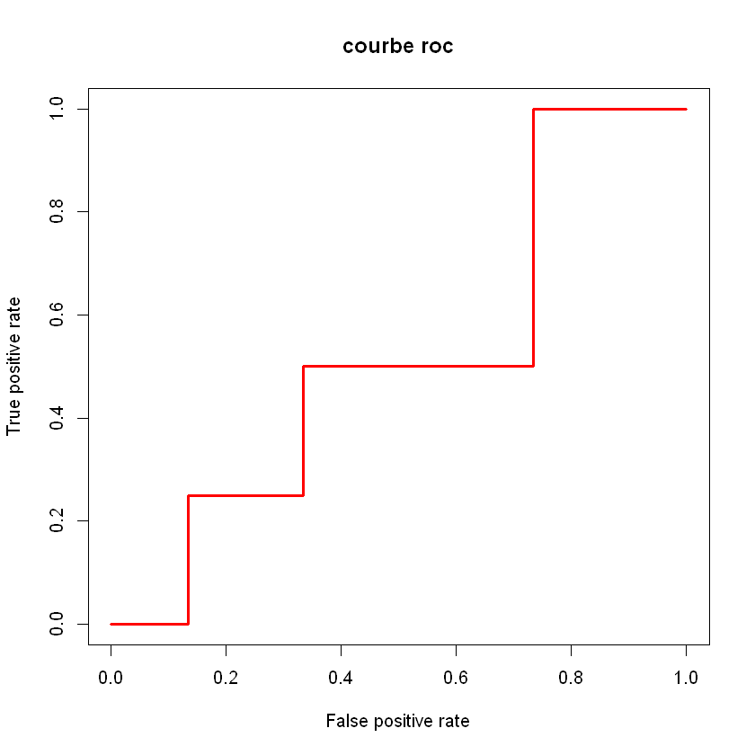

```r
plot(roc_curve ,main="courbe roc",col="red",lwd=3)
```

La courbe montre plusieurs paliers, qui représentent différents seuils.

- La surface sous la courbe ROC (AUC) est une mesure de la capacité d'un paramètre à distinguer entre deux groupes diagnostiques (malade/normal).

### Le package blorr pour évaluer un modèle de régression logistique binaire

```r
#blorr::eval_binomial(tes_data,prediction)
blr_confusion_matrix(final_model,cutoff=0.5)
```

```
Confusion Matrix and Statistics

          Reference
Prediction   0   1
         0 105  34
         1  10  21


                Accuracy : 0.7412
     No Information Rate : 0.6765

                   Kappa : 0.3327

McNemars's Test P-Value  : 5e-04

             Sensitivity : 0.3818
             Specificity : 0.9130
          Pos Pred Value : 0.6774
          Neg Pred Value : 0.7554
              Prevalence : 0.3235
          Detection Rate : 0.1235
    Detection Prevalence : 0.1824
       Balanced Accuracy : 0.6474
               Precision : 0.6774
                  Recall : 0.3818

        'Positive' Class : 1
```

La matrice de confusion montre la performance d'un classificateur binaire. On y voit 105 vrais négatifs et 21 vrais positifs, indiquant les prédictions correctes. * L'exactitude du modèle est de 74,12%, signifiant qu'il prédit correctement les issues 74,12% du temps. * La sensibilité (ou rappel) est de 38,18%, indiquant la proportion de positifs réels bien identifiés, tandis que la spécificité est de 91,30%, reflétant la proportion de négatifs réels bien identifiés. * La valeur prédictive positive est de 67,74%, et la valeur prédictive négative est de 75,54%, qui indiquent respectivement la probabilité que les prédictions de classe positive/négative soient correctes. * Le test de McNemar donne une valeur-p de 0,0005, ce qui peut indiquer une différence significative entre les taux de faux positifs et de faux négatifs. * Le Kappa de 0,3327 montre une concordance modérée au-delà du hasard entre la prédiction et la référence.

```r
# 6. Transformation des variables 'ftv' et 'ptl' en variables qualitatives
```

```r
birthwt$ftv = cut(birthwt$ftv, breaks = c(-Inf, 0, 1, 2, Inf), labels = c("0", "1", "2", "3+"), include.lowest = TRUE) # 4 MODALIT7B
birthwt$ptl = cut(birthwt$ptl, breaks = c(-Inf, 0, Inf), labels = c("0", "1+"), include.lowest = TRUE)  #2 Modalité
```

```r
birthwt$ftv
```

1. 0

2. 3+

3. 1

4. 2

5. 0

6. 0

7. 1

8. 1

9. 1

10. 0

11. 0

12. 1

13. 0

14. 2

15. 0

16. 0

17. 0

18. 3+

19. 0

20. 1

21. 2

22. 3+

23. 1

24. 0

25. 2

26. 0

27. 0

28. 2

29. 0

30. 1

31. 1

32. 1

33. 1

34. 1

35. 0

36. 2

37. 2

38. 0

39. 2

40. 1

41. 2

42. 2

43. 1

44. 0

45. 0

46. 0

47. 3+

48. 0

49. 2

50. 0

51. 1

52. 0

53. 0

54. 2

55. 0

56. 0

57. 0

58. 0

59. 0

60. 0

61. 0

62. 2

63. 0

64. 0

65. 0

66. 1

67. 2

68. 3+

69. 1

70. 2

71. 0

72. 2

73. 1

74. 0

75. 0

76. 0

77. 1

78. 3+

79. 0

80. 0

81. 1

82. 0

83. 0

84. 0

85. 0

86. 0

87. 0

88. 0

89. 0

90. 1

91. 0

92. 2

93. 0

94. 0

95. 0

96. 1

97. 1

98. 0

99. 0

100. 1

101. 1

102. 0

103. 0

104. 1

105. 0

106. 0

107. 1

108. 0

109. 2

110. 3+

111. 2

112. 1

113. 2

114. 1

115. 0

116. 1

117. 0

118. 0

119. 2

120. 1

121. 1

122. 0

123. 1

124. 0

125. 2

126. 2

127. 1

128. 0

129. 1

130. 1

131. 0

132. 2

133. 0

134. 0

135. 0

136. 0

137. 1

138. 1

139. 0

140. 1

141. 0

142. 0

143. 0

144. 1

145. 0

146. 2

147. 2

148. 0

149. 0

150. 0

151. 1

152. 2

153. 0

154. 0

155. 0

156. 0

157. 3+

158. 1

159. 0

160. 0

161. 0

162. 1

163. 0

164. 0

165. 0

166. 0

167. 3+

168. 0

169. 1

170. 0

171. 1

172. 0

173. 0

174. 0

175. 0

176. 0

177. 1

178. 3+

179. 0

180. 2

181. 1

182. 3+

183. 0

184. 0

185. 2

186. 2

187. 0

188. 0

189. 3+

**Levels**:**

1. '0'

2. '1'

3. '2'

4. '3+'

```r
#### 04 modalités
```

```r
birthwt$ptl
```

1. 0

2. 0

3. 0

4. 0

5. 0

6. 0

7. 0

8. 0

9. 0

10. 0

11. 0

12. 0

13. 0

14. 1+

15. 0

16. 0

17. 0

18. 0

19. 0

20. 0

21. 0

22. 0

23. 0

24. 0

25. 0

26. 0

27. 0

28. 0

29. 0

30. 0

31. 0

32. 1+

33. 1+

34. 0

35. 0

36. 0

37. 0

38. 0

39. 0

40. 0

41. 0

42. 0

43. 0

44. 0

45. 0

46. 0

47. 0

48. 0

49. 0

50. 0

51. 0

52. 0

53. 0

54. 0

55. 0

56. 0

57. 0

58. 0

59. 0

60. 0

61. 0

62. 0

63. 0

64. 0

65. 1+

66. 1+

67. 0

68. 0

69. 1+

70. 1+

71. 1+

72. 0

73. 0

74. 0

75. 0

76. 0

77. 0

78. 1+

79. 0

80. 0

81. 0

82. 0

83. 0

84. 0

85. 0

86. 0

87. 0

88. 0

89. 0

90. 0

91. 0

92. 0

93. 0

94. 1+

95. 0

96. 0

97. 0

98. 0

99. 0

100. 0

101. 0

102. 0

103. 1+

104. 0

105. 0

106. 0

107. 0

108. 0

109. 0

110. 0

111. 0

112. 0

113. 0

114. 0

115. 0

116. 0

117. 0

118. 0

119. 0

120. 0

121. 0

122. 0

123. 0

124. 0

125. 0

126. 0

127. 1+

128. 0

129. 0

130. 0

131. 1+

132. 0

133. 0

134. 1+

135. 0

136. 0

137. 0

138. 1+

139. 0

140. 0

141. 0

142. 1+

143. 0

144. 0

145. 0

146. 0

147. 0

148. 1+

149. 0

150. 0

151. 1+

152. 0

153. 0

154. 1+

155. 0

156. 1+

157. 0

158. 1+

159. 0

160. 0

161. 0

162. 1+

163. 0

164. 0

165. 1+

166. 1+

167. 1+

168. 0

169. 1+

170. 0

171. 0

172. 0

173. 0

174. 0

175. 0

176. 1+

177. 0

178. 0

179. 1+

180. 0

181. 1+

182. 0

183. 0

184. 1+

185. 0

186. 0

187. 0

188. 0

189. 0

**Levels**:**

1. '0'

2. '1+'

```r
#### 02 modalités
```

```r
# 7. Nouvelle division des données après codage
```

```r
indices_new = sample(1:nrow(birthwt), size = 0.9 * nrow(birthwt))
train_data_new = birthwt[indices_new, ]
test_data_new = birthwt[-indices_new, ]
```

```r
# Régression logistique binaire sur la nouvelle base de données
```

```r
model_new = glm(low ~ ., data = data_train, family = binomial())
summary(model_new)
```

```
Call:
glm(formula = low ~ ., family = binomial(), data = data_train)

Coefficients:
             Estimate Std. Error z value Pr(>|z|)
(Intercept)  0.592880   1.295482   0.458  0.64720
age         -0.009938   0.039124  -0.254  0.79949
lwt         -0.019890   0.007678  -2.591  0.00958 **
race2        1.258303   0.591231   2.128  0.03331 *
race3        1.034326   0.481480   2.148  0.03170 *
smoke1       1.140776   0.447225   2.551  0.01075 *
ptl          0.487070   0.361127   1.349  0.17742
ht1          1.943594   0.725173   2.680  0.00736 **
ui1          0.775038   0.495930   1.563  0.11810
ftv         -0.040027   0.190677  -0.210  0.83373
---
Signif. codes:  0 '***' 0.001 '**' 0.01 '*' 0.05 '.' 0.1 ' ' 1

(Dispersion parameter for binomial family taken to be 1)

    Null deviance: 214.03  on 169  degrees of freedom
Residual deviance: 178.66  on 160  degrees of freedom
AIC: 198.66

Number of Fisher Scoring iterations: 4
```

Le modèle de régression logistique indique que 'lwt', 'race2', 'race3', 'smoke1', et 'ht1' sont des prédicteurs statistiquement significatifs de la variable réponse 'low'. 'lwt' a une association négative, tandis que 'race2', 'race3', 'smoke1', et 'ht1' ont des associations positives. Les autres variables n'ont pas d'effet significatif sur la réponse à ce niveau de signification.

```r
model_new = glm(low ~ ., data = train_data_new, family = binomial())
model_step_new = step(model_new, trace = 0)
print(summary(model_step_new))
odds_ratios_new = odds.ratio(model_step_new)
print(odds_ratios_new)
```

[output not shown]

[output cut: 125 more lines]

[output not shown]

```
Call:
glm(formula = low ~ bwt, family = binomial(), data = train_data_new)

Coefficients:
              Estimate Std. Error z value Pr(>|z|)
(Intercept)  1.597e+03  1.917e+05   0.008    0.993
bwt         -6.325e-01  7.596e+01  -0.008    0.993

(Dispersion parameter for binomial family taken to be 1)

    Null deviance: 2.0936e+02  on 169  degrees of freedom
Residual deviance: 1.6279e-07  on 168  degrees of freedom
AIC: 4

Number of Fisher Scoring iterations: 25
```

[output not shown]

```
                    OR      2.5 % 97.5 %      p
(Intercept)        Inf        Inf    Inf 0.9934
bwt         5.3125e-01 1.9974e-12      0 0.9934
```

Pour la variable bwt (birth weight), l'odds ratio est 0.53125, mais les intervalles de confiance à 95% vont de pratiquement zéro à zéro, et la valeur p est très élevée (0.9934):

- ce qui suggère que cette variable pourrait ne pas être un prédicteur significatif de la variable de réponse low.
- L'odds ratio infini pour l'interception (Intercept) avec des intervalles de confiance également infinis et une valeur p très élevée indique des problèmes potentiels avec le modèle

```r
summary(model_step_new)
```

```
Call:
glm(formula = low ~ bwt, family = binomial(), data = train_data_new)

Coefficients:
              Estimate Std. Error z value Pr(>|z|)
(Intercept)  1.597e+03  1.917e+05   0.008    0.993
bwt         -6.325e-01  7.596e+01  -0.008    0.993

(Dispersion parameter for binomial family taken to be 1)

    Null deviance: 2.0936e+02  on 169  degrees of freedom
Residual deviance: 1.6279e-07  on 168  degrees of freedom
AIC: 4

Number of Fisher Scoring iterations: 25
```

=> Formule du Modèle : Le modèle est formé avec low ~ bwt, ce qui signifie que vous essayez de prédire la variable low en utilisant bwt comme variable explicative.

*** Coefficients :

- L'intercept est très élevé (1.597e+03), ce qui est inhabituel et pourrait indiquer des problèmes avec les données ou le modèle.
- Le coefficient pour bwt est -6.325e-01, mais sa signification statistique est faible (valeur p de 0.993), ce qui suggère qu'il n'a pas d'influence significative sur la prédiction de low.

*** Performance du Modèle :

- La dispersion est prise pour être 1, ce qui est typique pour la famille binomiale.
- La déviance résiduelle est extrêmement faible, ce qui est inhabituel et pourrait indiquer un surajustement ou d'autres problèmes avec le modèle.
- L'AIC (Akaike Information Criterion) est de 4, ce qui semble anormalement bas. Itérations : Le modèle a effectué 25 itérations de scoring de Fisher, ce qui est assez élevé et peut indiquer des difficultés à converger.

### 8. Évaluation avec blorr

```r
## 8. Évaluation des indicateurs de performance
```

```r
colnames(data_tes)
```

1. 'low'

2. 'age'

3. 'lwt'

4. 'race'

5. 'smoke'

6. 'ptl'

7. 'ht'

8. 'ui'

9. 'ftv'

```r
probs_new = predict(model_step_new, newdata = test_data_new, type = "response")
print(probs_new)
```

```
          85           87          118          143          145          146
6.732617e-01 9.421336e-10 2.220446e-16 2.220446e-16 2.220446e-16 2.220446e-16
         149          172          183          186          212          222
2.220446e-16 2.220446e-16 2.220446e-16 2.220446e-16 2.220446e-16 2.220446e-16
          19           22           26           27           37           47
1.000000e+00 1.000000e+00 1.000000e+00 1.000000e+00 1.000000e+00 1.000000e+00
          62
1.000000e+00
```

- Les numéros (comme 85, 87, 118, etc.) sont probablement des identifiants pour les observations ou les individus dans le jeu de données.
- Les valeurs comme 6.732617e-01 (soit environ 0.673) représentent la probabilité prédite pour l'observation correspondante selon le modèle. Dans ce cas, cela signifie que l'individu ou l'observation a environ 67.3% de chance d'appartenir à la classe positive (ou d'avoir l'issue prédite par le modèle).
- Les valeurs extrêmement faibles (proches de zéro, comme 2.220446e-16) suggèrent que le modèle prédit avec une quasi-certitude que ces observations n'appartiennent pas à la classe positive.
- Les valeurs de 1 indiquent que le modèle prédit avec certitude que ces observations appartiennent à la classe positive.

```r
# Les predictions
```

```r
preds_new =ifelse(probs_new > 0.5, 1, 0)
print(preds_new)
```

```
 85  87 118 143 145 146 149 172 183 186 212 222  19  22  26  27  37  47  62
  1   0   0   0   0   0   0   0   0   0   0   0   1   1   1   1   1   1   1
```

```r
# Matrice conf
```

```r
conf_matrix_new = table(Predicted = preds_new, Actual = test_data_new$low)
print(conf_matrix_new)
```

```
         Actual
Predicted  0  1
        0 11  0
        1  1  7
```

créé une matrice de confusion (conf_matrix_new) pour comparer ces prédictions (Predicted) avec les valeurs réelles (Actual) de notre jeu de données de test (test_data_new$low).

La matrice de confusion est la suivante :

- 11 observations sont correctement classées comme n'appartenant pas à la classe positive (vrais négatifs).
- 7 observations sont correctement classées comme appartenant à la classe positive (vrais positifs).
- 1 observation est incorrectement classée comme appartenant à la classe positive alors qu'elle n'en fait pas partie (faux positif). Il n'y a aucun faux négatif (observations incorrectement classées comme n'appartenant pas à la classe positive alors qu'elles en font partie).

### Calcul de l'AUC, sensibilité, spécificité, etc.

```r
pred_new = prediction(probs_new, test_data_new$low)
auc_value =as.numeric(performance(pred_new,"auc")@y.values)
auc_value
```

1

Interprétation de l'AUC : Une valeur AUC de 0,5 indique une performance équivalente à un hasard aléatoire. Une valeur AUC plus proche de 1,0 indique une meilleure capacité du modèle à distinguer correctement entre les classes positives et négatives. Une valeur AUC inférieure à 0,5 suggérerait que le modèle fait pire que le hasard, bien que cela soit rare dans la pratique

```r
roc_curve2=performance(pred_new,"tpr","fpr")
#perf = performance(pred, "tpr", "fpr")
roc_curve2
```

```
A performance instance
  'False positive rate' vs. 'True positive rate' (alpha: 'Cutoff')
  with 5 data points
```

- Taux de Vrais Positifs (True Positive Rate) : C'est la proportion des cas positifs réels qui sont correctement identifiés par le modèle. Il est aussi connu sous le nom de sensibilité ou de rappel.
- Taux de Faux Positifs (False Positive Rate) : C'est la proportion des cas négatifs réels qui sont incorrectement identifiés comme positifs par le modèle.
- Alpha : 'Cutoff' : Le seuil de décision ou le point de coupure est la valeur à partir de laquelle les prédictions sont classées comme positives ou négatives. Modifier ce seuil peut augmenter la sensibilité (en capturant plus de vrais positifs) au détriment de la spécificité (en augmentant les faux positifs), ou vice versa.

Avoir 5 points de données sur une courbe ROC signifie que vous avez analysé la performance du modèle à 5 seuils de coupure différents. Chaque point sur la courbe ROC représente un compromis différent entre le taux de vrais positifs et le taux de faux positifs.

[figure not shown]

```r
# Tracé de la courbe ROC
# Calcul de l'AUC, sensibilité, spécificité, etc.
plot(roc_curve2, main="Courbe ROC", col="red")
```

Si la courbe ROC est proche du coin supérieur gauche de la graphique, cela indique une performance élevée.

- Une courbe plus proche de la diagonale (de coin inférieur gauche à coin supérieur droit) suggère une performance qui n'est pas mieux que le hasard.

Dans cette courbe ROC, nous voyons une ligne qui monte directement à un taux de vrais positifs de 1 (ou 100%) sans aucun faux positif, puis se déplace horizontalement. Cela suggère que le modèle peut parfaitement distinguer entre les classes positives et négatives à un certain seuil de coupure sans erreur.

```r
#8
```

```r
#model_performance =blorr::blr_model_performance(model_step_new)
blr_confusion_matrix(model_step_new,cutoff=0.5)
```

```
Confusion Matrix and Statistics

          Reference
Prediction   0   1
         0 118   0
         1   0  52


                Accuracy : 1.0000
     No Information Rate : 0.6941

                   Kappa : 1.0000

McNemars's Test P-Value  : NaN

             Sensitivity : 1.0000
             Specificity : 1.0000
          Pos Pred Value : 1.0000
          Neg Pred Value : 1.0000
              Prevalence : 0.3059
          Detection Rate : 0.3059
    Detection Prevalence : 0.3059
       Balanced Accuracy : 1.0000
               Precision : 1.0000
                  Recall : 1.0000

        'Positive' Class : 1
```

- Matrice de confusion : Il n'y a aucun faux positif ni faux négatif. Chaque prédiction correspond à la référence.
- Exactitude (Accuracy) : 100%, signifiant que toutes les prédictions sont correctes.
- Taux d'information sans information (No Information Rate) : 69.41%, c'est le taux de succès que l'on aurait obtenu par une prédiction aléatoire basée sur la fréquence la plus élevée.
- Kappa : 1.0000, indiquant une concordance parfaite.
- Valeur-P du test de McNemar : Non applicable (NaN), probablement parce qu'il n'y a pas de discordance entre les prédictions positives et négatives.
- Sensibilité (Sensitivity) : 100%, toutes les vrais positifs sont identifiés correctement.
- Spécificité (Specificity) : 100%, tous les vrais négatifs sont identifiés correctement.
- Valeur Prédictive Positive (Pos Pred Value) : 100%, si le modèle prédit positif, il est correct.
- Valeur Prédictive Négative (Neg Pred Value) : 100%, si le modèle prédit négatif, il est correct.
- Prévalence : 30.59%, la fréquence de la classe positive dans l'ensemble des données.
- Taux de détection (Detection Rate) : 30.59%, la proportion de vrais positifs détectés par rapport à la population totale.
- Prévalence de détection (Detection Prevalence) : 30.59%, la proportion de prédictions positives.
- Exactitude Équilibrée (Balanced Accuracy) : 100%, moyenne de la sensibilité et de la spécificité.
- Précision (Precision) et Rappel (Recall) : 100%, indiquant que toutes les instances positives sont correctement identifiées sans erreur. Ces résultats pourraient indiquer que le modèle est trop bien ajusté aux données (surajustement

```r
## Interpretation
```

Si un seuil de coupure (cutoff) de 0.2 pour notre modèle , cela signifie que toutes les probabilités prédites supérieures ou égales à 0.2 seront classées comme positives (par exemple, la présence d'une condition ou d'un événement), tandis que celles en dessous de 0.2 seront classées comme négatives

- Sensibilité (True Positive Rate) : Elle va probablement augmenter parce que le modèle classera plus de cas comme positifs. Cela signifie que le modèle sera plus enclin à détecter les vrais positifs, mais au risque d'augmenter le nombre de faux positifs.
- Spécificité (False Positive Rate) : Elle va probablement diminuer, puisqu'un seuil plus bas signifie que le modèle est moins strict pour prédire une classe positive. Cela pourrait conduire à une augmentation des cas où les vrais négatifs sont incorrectement classés comme positifs.
- Valeur Prédictive Positive (Positive Predictive Value) : Elle pourrait diminuer parce que le modèle prédit plus de positifs, y compris de faux positifs, ce qui réduit la proportion de prédictions positives qui sont réellement correctes.
- Valeur Prédictive Négative (Negative Predictive Value) : Elle pourrait augmenter puisqu'il y aura moins de faux négatifs, mais cela dépend aussi de la prévalence de la condition dans la population.
- Précision (Accuracy) : Cela dépend de l'équilibre entre vrais positifs et faux positifs. Avec plus de faux positifs possibles, la précision globale pourrait diminuer si le nombre de faux positifs augmente significativement.

En conclusion, abaisser le seuil de coupure à 0.2 va probablement rendre le modèle plus sensible mais moins spécifique. Cela peut être utile dans des situations où manquer un vrai positif est critique (comme dans le dépistage préliminaire d'une maladie grave), mais cela peut également conduire à un grand nombre de faux positifs, qui pourraient entraîner des coûts supplémentaires ou des inquiétudes inutiles. L'évaluation de la performance du modèle avec le package blorr ou tout autre outil statistique devrait fournir des mesures quantitatives de ces effets pour une interprétation plus précise et fondée sur des données.